# ANXIOUS OR ANGRY - EFFECTS OF DISCRETE EMOTIONS ON THE PERCEIVED HELPFULNESS OF ONLINE REVIEWS

Gao Baojun @WHU, sinkgao@gmail.com

2022-06-20

# The Data

### Import Data

```r
#review <- read.csv(".\\review.csv", stringsAsFactors = FALSE, header = TRUE)
load("review.Rdata")
load("review_tdm_df.Rdata")
load("review_tdm.Rdata")
load("review_tm.Rdata")
```

### Fliter non-english and non-valid-UTF-8 reviews

```r
#identify non-valid-UTF-8-characters in a string and delete them
review$ReviewText <- iconv(review$ReviewText, "UTF-8", "UTF-8",sub='')

#identify languages
review$language <- textcat(review$ReviewText)

#filter english review
review <-
  review %>%
  filter(language == "english")
```

# Count data model

### Poisson Regression

The simplest distribution used for modeling count data is the Poisson distribution with probability density function:
$$f(y;\mu )=\frac{exp(-\mu)\cdot
\mu^{y}}{y!}$$
The canonical link is g($\mu$) = log($\mu$) resulting in a log-linear relationship between mean and linear predictor. In R, this can easily be specied in the glm() call just by setting family = poisson.

```r
glm(formula, data, family = poisson, start = NULL,
model = TRUE, y = TRUE, x = FALSE, ...)
```

### Negative Binomial Regression

Another way of modeling over-dispersed count data is to assume a negative binomial (NB) distribution for $y_{i}|x_{i}$ which can arise as a gamma mixture of Poisson distributions
$$f(y;\mu,\theta )=\frac{\tau
(y+\theta)}{\tau(\theta)}\cdot
\frac{\mu^{y}\cdot\theta^{\theta}}{(\mu+\theta)^{y+\theta}}$$
the function glm.nb() from the package MASS can give the result

```r
glm.nb(formula, data, weights, start = NULL,
       control = glm.control(...), method = "glm.fit",
       model = TRUE, x = FALSE, y = TRUE, contrasts = NULL, ...,
       init.theta, link = log)
```

### The distribution of NumHelpful -Why use NB Model

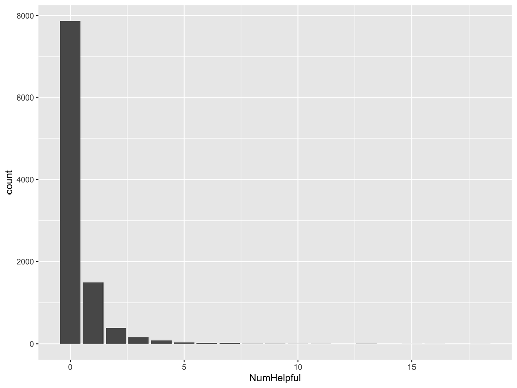

# What the literature tells us

- Reviewer specific variables

> Age

> Gender

> Identity disclosure
- Review specific variables

> Rating

> Rating deviation

> Length of review

> Readability of review
- Hotel fixed effect
- Time fixed effect

# Data Processing

### Reviewer specific variables

- Construct Not_Disclosure variable

  Gender 和Age是重要的控制变量，这两个数据都是从文本中解析而来，观察这两个变量的取值和分布可以发现不是每个用户都披露了该信息。

  因此,构建一个变量Not_Disclosure,如果Gender Age中有其中之一为NA, 则Not_Disclosure = TRUE。

  原因是文献表明,身份披露会影响用户的在线行为。
- Construct women variable

  Gender有三种状态,构建一个变量women,women = TRUE if Gender = “female”
- Construct Age variable

  数据中Age为字符类型，观察其分布。由于Age的类型太多，可以将其合并为三组,分别用如下三个变量表示。

  YoungAge = TRUE, if Age < 34

  MidAge = TRUE, if Age 介于 35~49之间

  OldAge = TRUE, if Age > 50

### Review specific variables

- Construct rating deviation variable

  文献表明,极端的评论更容易得到Helpful Votes，因此要控制这个因素。

  Obs_Avg_Rating 是每个人写评论时观测到的平均评分，是根据完整的历史数据计算出来的。计算该变量(数据中已给出，可用于check)，并构造rating deviation。

```r
review <- review %>%
  mutate(Rating_Deviation = abs(AvgRatingStarsThisUser - Obs_Avg_Rating))
```

- Construct word count variable

  计算字数，用来求 Angry Anxious词汇的百分比。

### Hotel fixed effect

- 将HotelID转变为factor，用来控制Hotel FE

### Time fixed effect

- 抽取出year,并将其转化为factor，用来控制时间固定效应。
- 理论上，控制year-month更好，但是更多的dummy会导致Model求解困难，只考虑year是为了简化计算。

# Baseline Model

### Regression without fixed effect

```r
fit1= glm.nb(NumHelpful~
               AvgRatingStarsThisUser +
               Rating_Deviation +
               log(WC) +
               Not_Disclosure +
               women +
               MidAge +
               OldAge,
              review,link = log)
```

### Regression with fixed effect

```r
fit2= glm.nb(NumHelpful~
               AvgRatingStarsThisUser +
               Rating_Deviation +
               log(WC)+
               Not_Disclosure +
               women +
               MidAge +
               OldAge +
               HotelID+
               year,
             review,
             link = log)
```

### Output the results

输出规范的三线表，实践中输出为html，再进行编辑效果更佳。

```r
stargazer(list(fit1,fit2),type = "text",omit = c("HotelID","year"))
```

```
##
## ========================================================
##                               Dependent variable:
##                        ---------------------------------
##                                   NumHelpful
##                              (1)              (2)
## --------------------------------------------------------
## AvgRatingStarsThisUser    -0.101***        -0.175***
##                            (0.019)          (0.018)
##
## Rating_Deviation           0.296***         0.239***
##                            (0.032)          (0.027)
##
## log(WC)                    0.642***         0.376***
##                            (0.033)          (0.029)
##
## Not_Disclosure            -0.479***         -0.305**
##                            (0.158)          (0.126)
##
## women                       -0.235          -0.248*
##                            (0.154)          (0.127)
##
## MidAge                      -0.196           -0.228
##                            (0.179)          (0.145)
##
## OldAge                     -0.376*          -0.270*
##                            (0.199)          (0.164)
##
## Constant                  -3.463***          -0.076
##                            (0.245)          (0.455)
##
## --------------------------------------------------------
## Observations                10,044           10,044
## Log Likelihood            -7,251.098       -6,207.189
## theta                  0.488*** (0.025) 2.198*** (0.210)
## Akaike Inf. Crit.         14,518.190       12,510.380
## ========================================================
## Note:                        *p<0.1; **p<0.05; ***p<0.01
```

# 文本预处理

### Corpus

生成文本语预料Corpus对象，并查看

### 标准化预处理

- 转化为小写
- 去除标点
- 去除数字
- 去除停止词
- 去除多余空白
- 词干化

### TDM matrix

- 生成TDM矩阵

# TF-IDF

### 底层构建TF-IDF

- 尝试手工计算TF-IDF

```
## [1] 0.75
```

```
## [1] 7065
```

```
## [1] 1.421656
```

```
## [1] 1.066242
```

```
## [1] 0.05686624
```

### weightTfIdf计算

- 手工计算weightTfIdf

```
## [1] 0.0203029
```

```
## [1] 0.0203029
```

# 词云

### 使用wordcloud 和quanteda生成词云，并进行比较

### 研究特定数据子集的词云，并进行比较，如

- 比较老龄用户评论词云和年轻用户评论词云，观察其区别。
- 比较2012年之前发布的评论词云与2012年之后发布的评论词云，观察其区别。
- 研究不同rating的词云。
- 去除一些高频且无实际意义的停用词后，再回答上述问题。

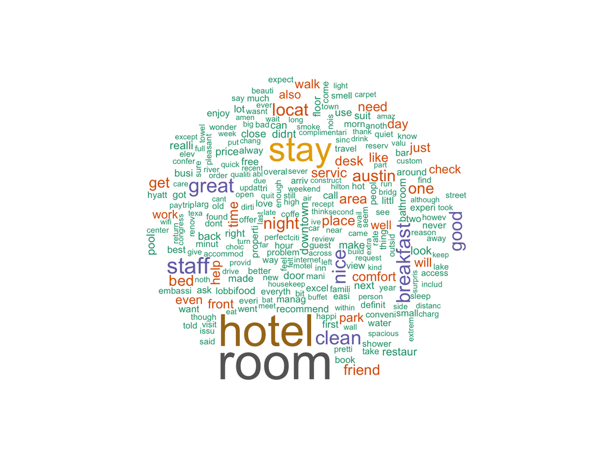

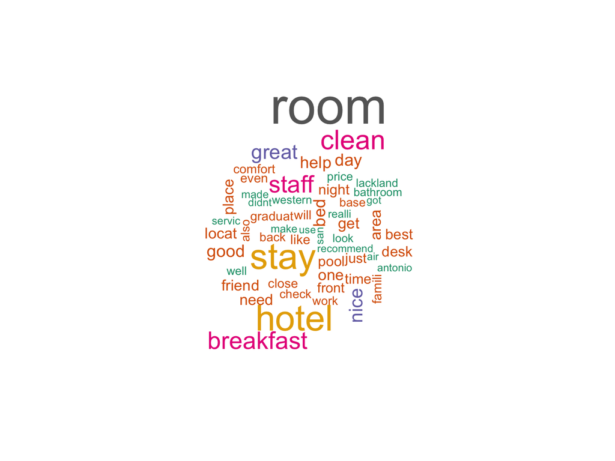

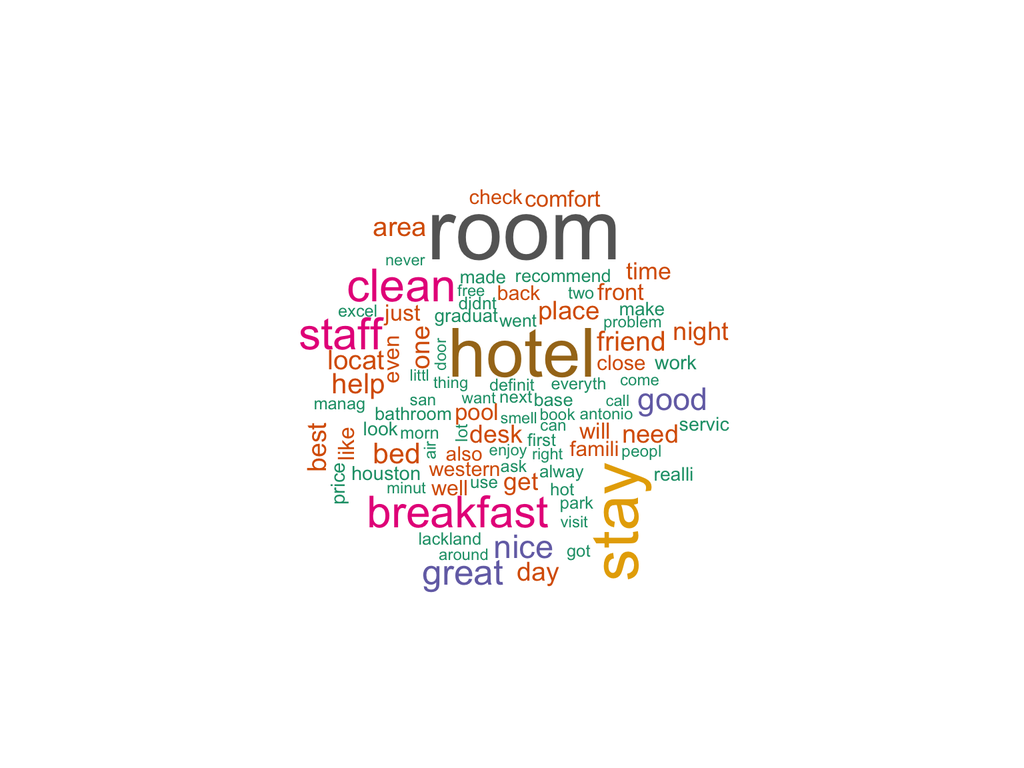

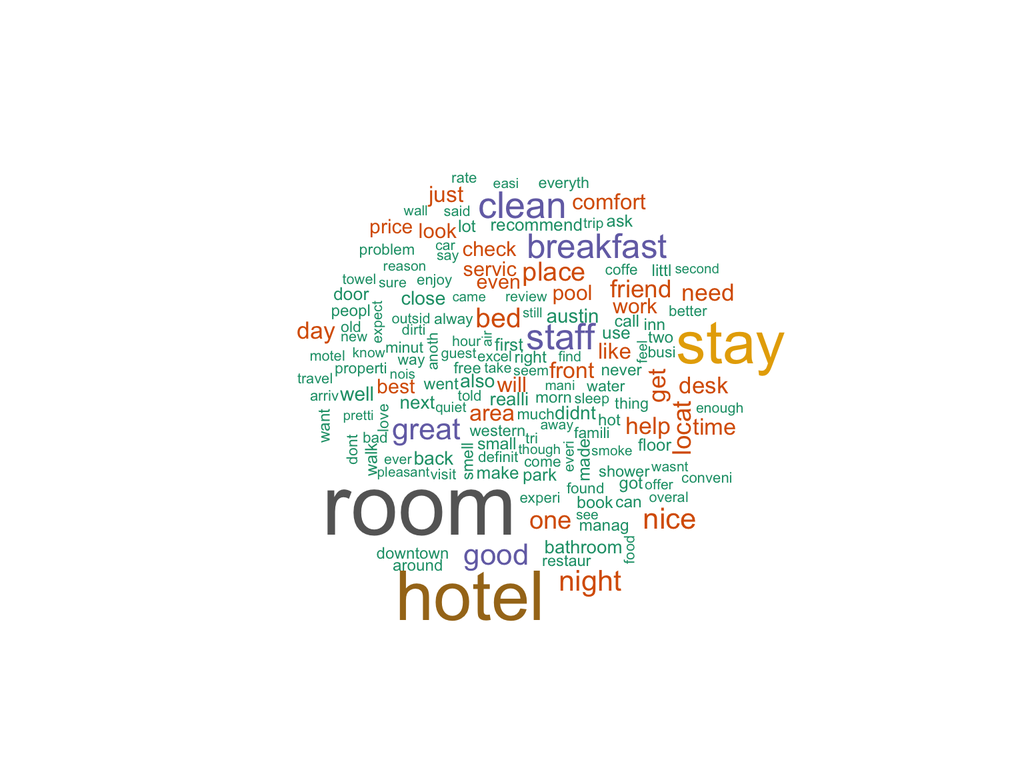

# Construct angry and anxious variables

### Construct angry and anxious variable

- 基于下面的词表，计算预料中angry & anxious 的比例，作为研究变量，分别记为 angry & anxious。要点如下
- 使用DocumentTermMatrix 生成angry & anxious的DTM
- 将angry相关的词频相加，除以WC，所得到的比例保存在dataframe中，得到anry变量；anxious变量类似。

```r
 #import angry dictionary
angry_dictionary <- c("abuse","aggress","anger","angry","annoy","argh","assault",
                      "asshole","attack","battl","bastard","beaten","bitch","bitter",
                      "blam","bother","cheat","confront","contempt","crap","critical",
                      "cruel","damn","destroy","destruct","dumb","dummy","enemy","envy",
                      "fiery","fight","foe","fuck","greed","hate","hell","idiot","insult",
                      "jealous","jerk","kill","lie","mad","mock","offence","pest","protest",
                      "rage","rude","shit","snob","stupid","suck","temper","trick","ugly",
                      "war","wick","yell")
```

```r
  #import anxious dictionary
anxious_dictionary <- c("afarid","alarm","anxiety","anxious","asham","avoid","awkward",
                        "confuse","desperat","discomfort","distress","disturb","doubt",
                        "embarrass","fear","frantic","guilt","horrible","humiliat",
                        "indecis","inhibit","nervous","obsess","overwhelm","panic",
                        "pressur","repress","rigid","risk","scare","shake","shy","tense",
                        "timid","uncertain","unsure","upset","worry")
```

# Readability & Sentiment

### Construct Readability variable

- 使用textstat_readability 计算Flesch.Kincaid指标。

### Construct sentiment variable

- 使用syuzhet::get_sentiment计算sentiment，结果保存为sentiment, NB模型使用这一指标。
- 使用quanteda计算sentiment，进行稳健性检验。

# Text metric regression

### 加入文本变量后的回归

```r
fit3= glm.nb(NumHelpful~
               angry +
               anxious +
               readability +
               sentiment ,
             review,link = log)
```

### 加入固定效应后

```r
fit4= glm.nb(NumHelpful~
               angry +
               anxious +
               readability +
               sentiment +
               HotelID +
               year,
             review,link = log)
```

### 加入控制变量后

```r
fit5= glm.nb(NumHelpful~
               AvgRatingStarsThisUser +
               Rating_Deviation +
               log(WC)+
               Not_Disclosure +
               women +
               MidAge +
               OldAge +
               angry +
               anxious +
               readability +
               sentiment +
               HotelID +
               year,
             review,link = log)
```

### Output the results

- 一切正确的话，应当得到下表的结果。

```
##
## =========================================================================
##                                       Dependent variable:
##                        --------------------------------------------------
##                                            NumHelpful
##                              (1)              (2)              (3)
## -------------------------------------------------------------------------
## AvgRatingStarsThisUser                                      -0.170***
##                                                              (0.022)
##
## Rating_Deviation                                             0.237***
##                                                              (0.027)
##
## log(WC)                                                      0.380***
##                                                              (0.033)
##
## Not_Disclosure                                               -0.309**
##                                                              (0.126)
##
## women                                                        -0.251**
##                                                              (0.127)
##
## MidAge                                                        -0.233
##                                                              (0.145)
##
## OldAge                                                       -0.273*
##                                                              (0.164)
##
## angry                      0.291***         0.199***          -0.009
##                            (0.069)          (0.059)          (0.063)
##
## anxious                    0.206***         0.149***          0.074*
##                            (0.049)          (0.037)          (0.038)
##
## readability                0.025***         0.011***          0.001
##                            (0.005)          (0.004)          (0.004)
##
## sentiment                   0.014*         -0.019***          -0.001
##                            (0.007)          (0.007)          (0.007)
##
## Constant                  -1.324***         1.474***          -0.104
##                            (0.050)          (0.458)          (0.462)
##
## -------------------------------------------------------------------------
## Observations                10,044           10,044           10,044
## Log Likelihood            -7,585.263       -6,497.736       -6,205.556
## theta                  0.336*** (0.015) 1.382*** (0.107) 2.207*** (0.211)
## Akaike Inf. Crit.         15,180.530       13,085.470       12,515.110
## =========================================================================
## Note:                                         *p<0.1; **p<0.05; ***p<0.01
```

# Extension:Understanding the Relationships of Variables

- 下列结果有何启示？

### Regression without control variables

```r
model1 <- polr(factor(AvgRatingStarsThisUser) ~ sentiment,data = review,Hess = TRUE)

model2 <-lm(sentiment ~ factor(AvgRatingStarsThisUser),data = review)
```

### Regression with control variables

```r
model3 <- polr(factor(AvgRatingStarsThisUser) ~
                 sentiment +
                 factor(HotelID) +
                 year +
                 log(WC) +
                 Not_Disclosure +
                 women +
                 MidAge +
                 OldAge,data = review,Hess = TRUE)

model4 <-lm(sentiment ~
              factor(AvgRatingStarsThisUser) +
              factor(HotelID) +
              year +
              log(WC) +
              Not_Disclosure +
              women +
              MidAge +
              OldAge,data = review)
```

### output the results

```r
stargazer(list(model1,model3, model2,model4),type = "text",omit = c("HotelID","year"))
```

```
##
## ===============================================================================================================
##                                                               Dependent variable:
##                                 -------------------------------------------------------------------------------
##                                 AvgRatingStarsThisUser                         sentiment
##                                         ordered                                   OLS
##                                        logistic
##                                     (1)         (2)                 (3)                         (4)
## ---------------------------------------------------------------------------------------------------------------
## sentiment                        0.366***    0.451***
##                                   (0.007)     (0.009)
##
## log(WC)                                      -1.550***                                        2.085***
##                                               (0.035)                                         (0.037)
##
## Not_Disclosure                                0.279*                                           0.135
##                                               (0.147)                                         (0.186)
##
## women                                        0.438***                                          0.070
##                                               (0.138)                                         (0.172)
##
## MidAge                                         0.088                                          -0.0001
##                                               (0.164)                                         (0.207)
##
## OldAge                                         0.140                                           0.350
##                                               (0.175)                                         (0.217)
##
## factor(AvgRatingStarsThisUser)2                                   1.136***                    1.401***
##                                                                   (0.120)                     (0.103)
##
## factor(AvgRatingStarsThisUser)3                                   2.950***                    3.311***
##                                                                   (0.108)                     (0.096)
##
## factor(AvgRatingStarsThisUser)4                                   4.656***                    5.073***
##                                                                   (0.101)                     (0.094)
##
## factor(AvgRatingStarsThisUser)5                                   5.108***                    5.783***
##                                                                   (0.098)                     (0.094)
##
## Constant                                                         -0.221***                   -9.015***
##                                                                   (0.086)                     (1.115)
##
## ---------------------------------------------------------------------------------------------------------------
## Observations                      10,044      10,044               10,044                      10,044
## R2                                                                 0.291                       0.491
## Adjusted R2                                                        0.291                       0.488
## Residual Std. Error                                          2.783 (df = 10039)          2.363 (df = 9994)
## F Statistic                                             1,030.253*** (df = 4; 10039) 196.645*** (df = 49; 9994)
## ===============================================================================================================
## Note:                                                                               *p<0.1; **p<0.05; ***p<0.01
```